# GLM para dados Contínuos

## 2 Explorando a distribuição da variável resposta

- Os dados não variaram ao longo do tempo, exceto em 2 anos pontuais que atingiu valores extremos.

```r
##criando variavel tempo
library(dplyr)
dados <- dados %>%
  mutate(tempo = paste(ano, meses, sep = "-"))
```

- Transformando os dados de acordo com a natureza do dados *factor*.

```r
# Transformando as variaveis
#~~~~~~~~~~~~~~~~~~~~~~~~~~~~~~~~~~~~~
## character -> vector
dados[, c("periodo_volume", "classif_volume", "classif_kmeans")] <- lapply(dados[, c("periodo_volume", "classif_volume", "classif_kmeans")], factor)
```

- visualizando a distribuição da razão zoo/fito ao longo do tempo.
- Os dados tem uma calda longa à direita, com poucas observações de valor alto.

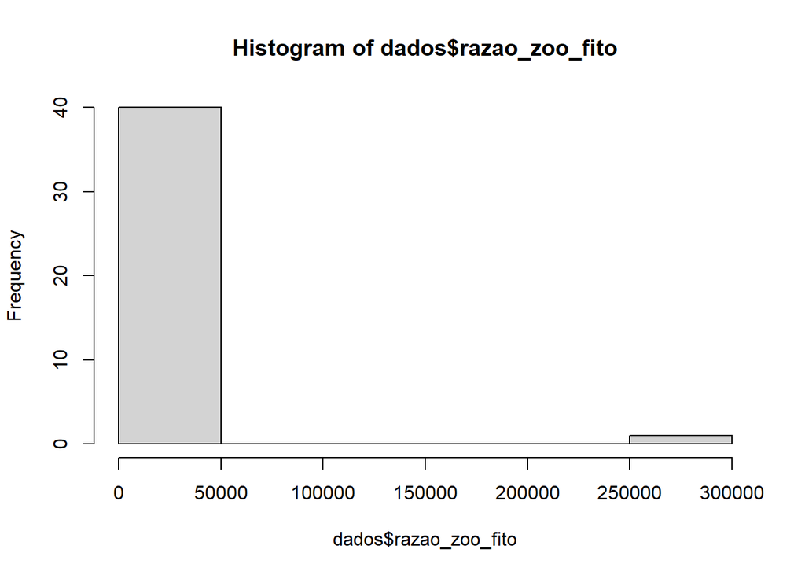

```r
##Distribuicao dos dados (variavel y)
hist(dados$razao_zoo_fito)
```

```r
summary(dados$razao_zoo_fito)
```

```
##      Min.   1st Qu.    Median      Mean   3rd Qu.      Max.
##      0.86    203.18   1759.68  11095.90   4955.95 253504.28
```

- verificando dinâmica anual e temporal da razão zoo/fito.

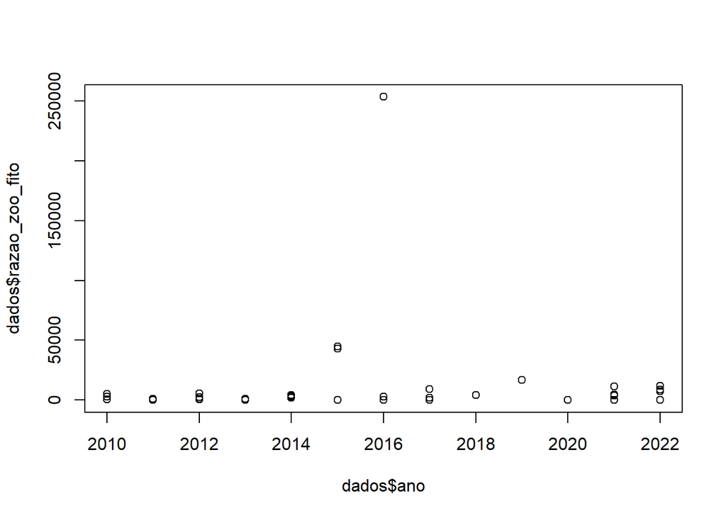

```r
##Dinamica anual
plot(dados$razao_zoo_fito ~ dados$ano)
```

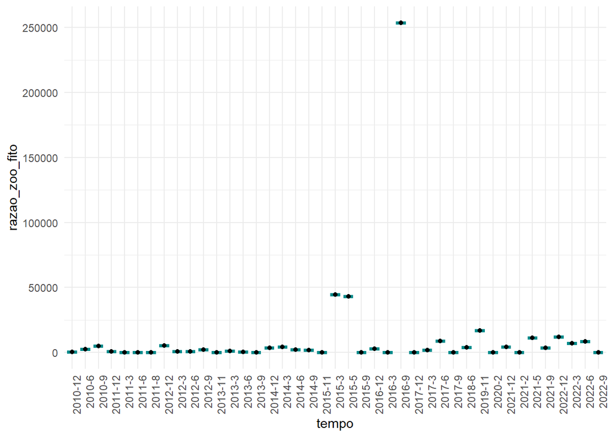

```r
library(ggplot2)
ggplot(dados, aes(x = tempo, y = razao_zoo_fito)) +
  geom_boxplot(size = 0.7, fill = 'cyan4',col = 'cyan4', alpha = 0.15) +
  stat_summary(fun = mean, geom="point", shape=19, size=1.5, color="black") +
  theme_minimal()+
  theme(axis.text.x = element_text(angle = 90, hjust = 1))
```

- não há uma tendência clara ao longo do tempo, exceto entre 2015 e 2016 que o valor da razão foi bem alto.

## 3 Escolhendo variáveis para os modelos

- Para construir o modelo para entender a variação da razão zoo/fito, é importante avaliar a multicolinearidade das variáveis.

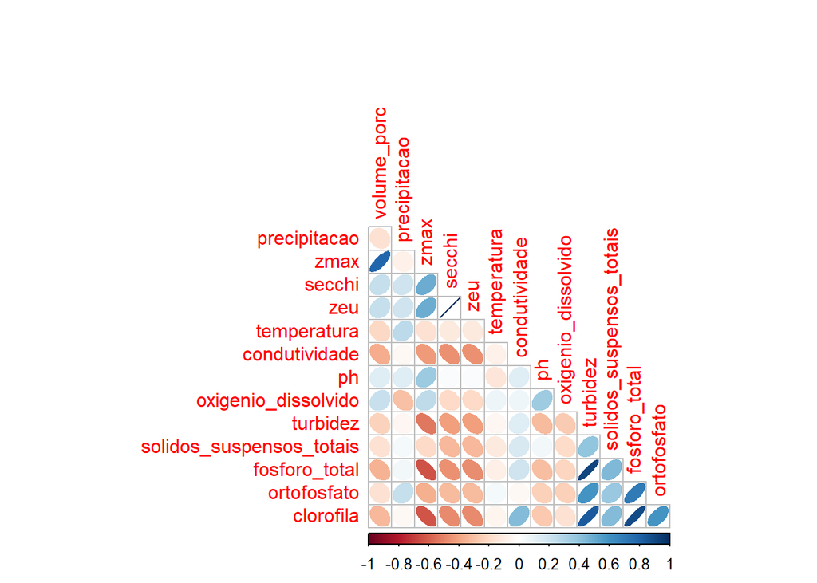

```r
#verificando colinearidade entre variaveis ambientais
library(GGally) #pairsplot
library(corrplot)
m_cor <- cor(dados[, 4:17])

corrplot(m_cor, method = 'ellipse', diag = FALSE, type = 'lower')
```

## 4 Hipóteses

Com base nessas breves observações, pensei em algumas hipóteses:

- $H_1:$ A razão tende a diminuir devido à intensificação da eutrofizaçao;
- $H_2:$ O aumento do fósforo total afeta negativamente a razão;
- $H_3:$ O aumento da profunidade, devido a uma maior precipitação, melhora o estado trófico da água, permitindo uma maior razão;
- $H_4:$ Mudanças na comunidade fitoplanctônica durante a seca afetam positivamente a razão zoo/fito, mesmo que momentaneamente.

## 5 Modelo GLM Gamma

- Comecei com o modelo glmmTMB e glm com family=gamma, link=“log”.
- Comecei com um modelo cheio - com todas variáveis pensadas na hipótese, depois sequencialmente eliminei variáveis nçao significativa até chegar a um modelo mais simples. Antes, padronizei as variáveis ambientais usando *scale*.

```r
#padronizando variaveis ambientes esolhidas para o modelo
dados_variaveis <- as.data.frame(scale(dados[, c(6, 5, 7, 15)]))
dados_razao_periodo <-dados[, c(18, 22)]

dados_completos <- cbind(dados_variaveis, dados_razao_periodo)
```

- modelos

```r
## Modelo Gama ##
library(glmmTMB)
modelo_G1 <- glmmTMB(razao_zoo_fito ~ zmax + fosforo_total
                     +precipitacao + secchi + classif_volume,
                    family = Gamma(link = "log"),
                    data = dados_completos)
summary(modelo_G1)
```

```
##  Family: Gamma  ( log )
## Formula:
## razao_zoo_fito ~ zmax + fosforo_total + precipitacao + secchi +
##     classif_volume
## Data: dados_completos
##
##       AIC       BIC    logLik -2*log(L)  df.resid
##     729.1     742.8    -356.6     713.1        33
##
##
## Dispersion estimate for Gamma family (sigma^2): 1.63
##
## Conditional model:
##                         Estimate Std. Error z value Pr(>|z|)
## (Intercept)              7.58365    0.71518  10.604   <2e-16 ***
## zmax                    -1.64317    0.66861  -2.458    0.014 *
## fosforo_total           -2.82799    0.32750  -8.635   <2e-16 ***
## precipitacao            -0.05001    0.20544  -0.243    0.808
## secchi                   0.43014    0.28422   1.513    0.130
## classif_volumeseca       1.29073    1.37143   0.941    0.347
## classif_volumetransicao -0.58190    0.84208  -0.691    0.490
## ---
## Signif. codes:  0 '***' 0.001 '**' 0.01 '*' 0.05 '.' 0.1 ' ' 1
```

```r
#sem precipitacao
modelo_G2 <- glmmTMB(razao_zoo_fito ~ zmax + fosforo_total
                      + secchi + classif_volume,
                     family = Gamma(link = "log"),
                     data = dados_completos)
summary(modelo_G2)
```

```
##  Family: Gamma  ( log )
## Formula:
## razao_zoo_fito ~ zmax + fosforo_total + secchi + classif_volume
## Data: dados_completos
##
##       AIC       BIC    logLik -2*log(L)  df.resid
##     727.2     739.2    -356.6     713.2        34
##
##
## Dispersion estimate for Gamma family (sigma^2): 1.63
##
## Conditional model:
##                         Estimate Std. Error z value Pr(>|z|)
## (Intercept)               7.6126     0.7170  10.618   <2e-16 ***
## zmax                     -1.6535     0.6755  -2.448   0.0144 *
## fosforo_total            -2.8300     0.3318  -8.530   <2e-16 ***
## secchi                    0.4180     0.2779   1.504   0.1325
## classif_volumeseca        1.2356     1.3828   0.894   0.3715
## classif_volumetransicao  -0.6121     0.8382  -0.730   0.4652
## ---
## Signif. codes:  0 '***' 0.001 '**' 0.01 '*' 0.05 '.' 0.1 ' ' 1
```

```r
#sem secchi
modelo_G3 <- glmmTMB(razao_zoo_fito ~ zmax + fosforo_total
                     + classif_volume,
                     family = Gamma(link = "log"),
                     data = dados_completos)
summary(modelo_G3)
```

```
##  Family: Gamma  ( log )
## Formula:          razao_zoo_fito ~ zmax + fosforo_total + classif_volume
## Data: dados_completos
##
##       AIC       BIC    logLik -2*log(L)  df.resid
##     727.5     737.8    -357.8     715.5        35
##
##
## Dispersion estimate for Gamma family (sigma^2):  1.7
##
## Conditional model:
##                         Estimate Std. Error z value Pr(>|z|)
## (Intercept)               7.1863     0.6649  10.808  < 2e-16 ***
## zmax                     -1.1615     0.6353  -1.828   0.0675 .
## fosforo_total            -2.8085     0.3434  -8.179 2.86e-16 ***
## classif_volumeseca        1.9551     1.3706   1.426   0.1538
## classif_volumetransicao   0.1063     0.6971   0.152   0.8788
## ---
## Signif. codes:  0 '***' 0.001 '**' 0.01 '*' 0.05 '.' 0.1 ' ' 1
```

```r
#sem secchi com glm e nao glmmTMB
modelo_G3glm <- glm(razao_zoo_fito ~ zmax + fosforo_total
                     + classif_volume,
                     family = Gamma(link = "log"),
                     data = dados_completos)
summary(modelo_G3glm)
```

```
##
## Call:
## glm(formula = razao_zoo_fito ~ zmax + fosforo_total + classif_volume,
##     family = Gamma(link = "log"), data = dados_completos)
##
## Coefficients:
##                         Estimate Std. Error t value Pr(>|t|)
## (Intercept)               7.1864     0.5920  12.139 2.75e-14 ***
## zmax                     -1.1615     0.5358  -2.168   0.0369 *
## fosforo_total            -2.8085     0.2597 -10.815 7.35e-13 ***
## classif_volumeseca        1.9550     1.1907   1.642   0.1093
## classif_volumetransicao   0.1062     0.6394   0.166   0.8690
## ---
## Signif. codes:  0 '***' 0.001 '**' 0.01 '*' 0.05 '.' 0.1 ' ' 1
##
## (Dispersion parameter for Gamma family taken to be 1.444275)
##
##     Null deviance: 207.061  on 40  degrees of freedom
## Residual deviance:  86.371  on 36  degrees of freedom
## AIC: 728.78
##
## Number of Fisher Scoring iterations: 12
```

- verificando AIC dos modelos
- o modelo com menor AIC foi o 2: razao_zoo_fito ~ zmax + fosforo_total + secchi + classif_volume
- A variação do AIC entre G2, G3, ambos glmmTMB e o glm, não foi tão grande.

```r
## Calcular os valores de AIC ##
aic <- AIC(modelo_G1, modelo_G2, modelo_G3, modelo_G3glm)


## Ordenar dos menores aos maiores valores ##
aic %>% arrange(-AIC)
```

```
##              df      AIC
## modelo_G1     8 729.1354
## modelo_G3glm  6 728.7828
## modelo_G3     6 727.5130
## modelo_G2     7 727.1936
```

## 6 Verificando resíduos simulados dos modelos com menor AIC

- O modelo G3 com efeito misto glmmTMB e o modelo glm padrão, ambos com a familia Gamma, são os mais simples, com menos variáveis.

Comparei os resíduos simulados para avaliar qual modelo melhor se adequou aos dados, incluindo o modelo 2 com menor AIC.

```r
library(DHARMa)
library(performance)

### Avaliando o comportamento geral dos residuos
check_model(modelo_G2)
```

```
## `check_outliers()` does not yet support models of class `glmmTMB`.
```

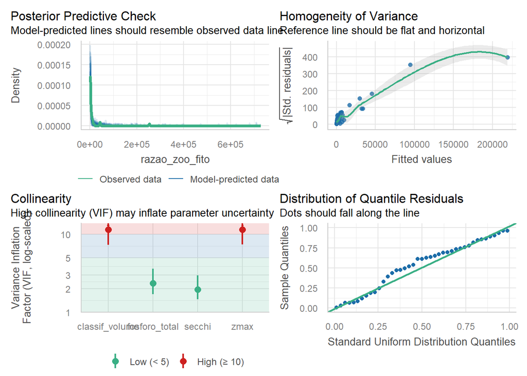

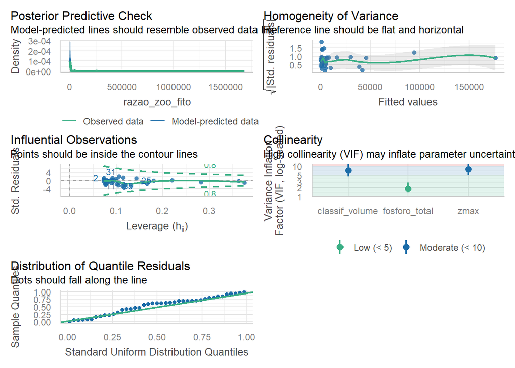

```r
### Avaliando o comportamento geral dos residuos
library(DHARMa)
library(performance)
check_model(modelo_G3glm)
```

- modelo g3 sem glmmTMB, problema com homocedasticidade, melhor que o modelo 2.

```r
library(DHARMa)
library(performance)
### Avaliando o comportamento geral dos residuos
check_model(modelo_G3)
```

```
## `check_outliers()` does not yet support models of class `glmmTMB`.
```

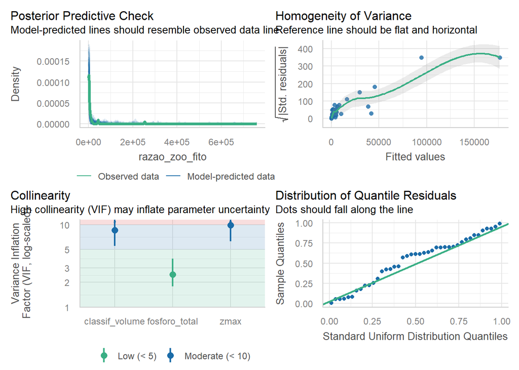

- modelo 3 com glmmTMB, melhor que o modelo 2, mas um pouco pior que o modelo 3 anterior.

## 7 Deduções

- É possível perceber que há problemas com a homocedasticidade dos resíduos tanto no modelo 3 com glmmTMB e glm. No glm ficou um pouco melhor.
- No glmmTMB também tive problema de colinearidade entre zmax e período hidrológico, mas não muito alto.

Mas de modo geral, os modelos se adequaram consideravelmente aos dados.

- plotando o predito da razão zoo/fito versus o observado.

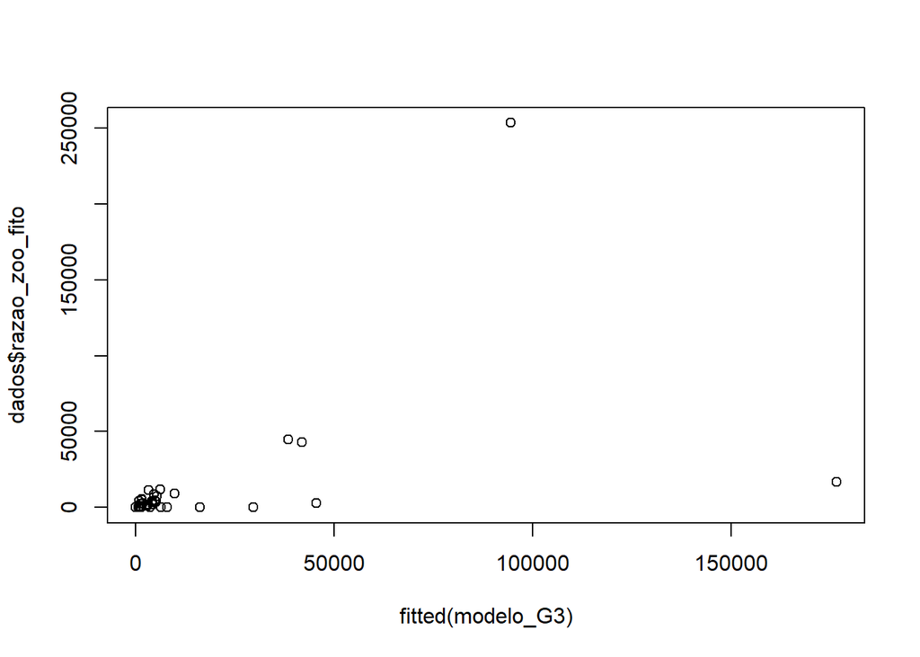

```r
## grafico predito versus observados
plot(dados$razao_zoo_fito ~ fitted(modelo_G3))
```

- verificando autocorrelação temporal

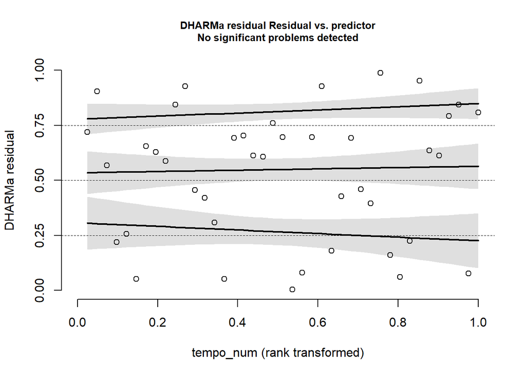

```r
### Avaliando a correlacao temporal
res <- simulateResiduals(fittedModel = modelo_G3)

#recalculando os resíduos por grupo temporal
res_tempo <- recalculateResiduals(res, group = dados$tempo_num)

#visualizando o teste autocorrelação temporal
plotResiduals(res_tempo, dados$tempo_num)
```

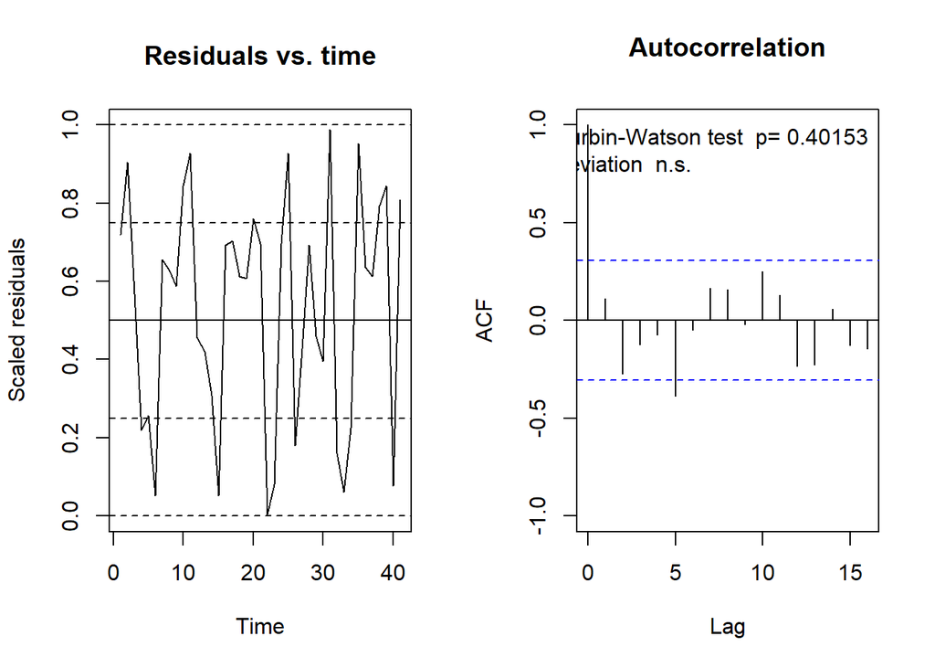

```
##
##  Durbin-Watson test
##
## data:  simulationOutput$scaledResiduals ~ 1
## DW = 1.7409, p-value = 0.4015
## alternative hypothesis: true autocorrelation is not 0
```

```r
testTemporalAutocorrelation(res, time = dados$tempo_num)
```

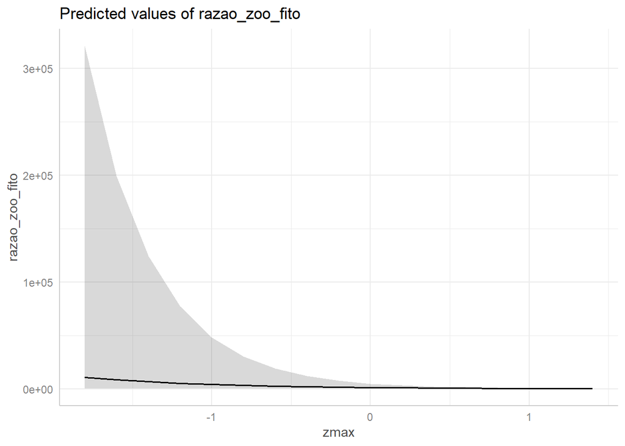

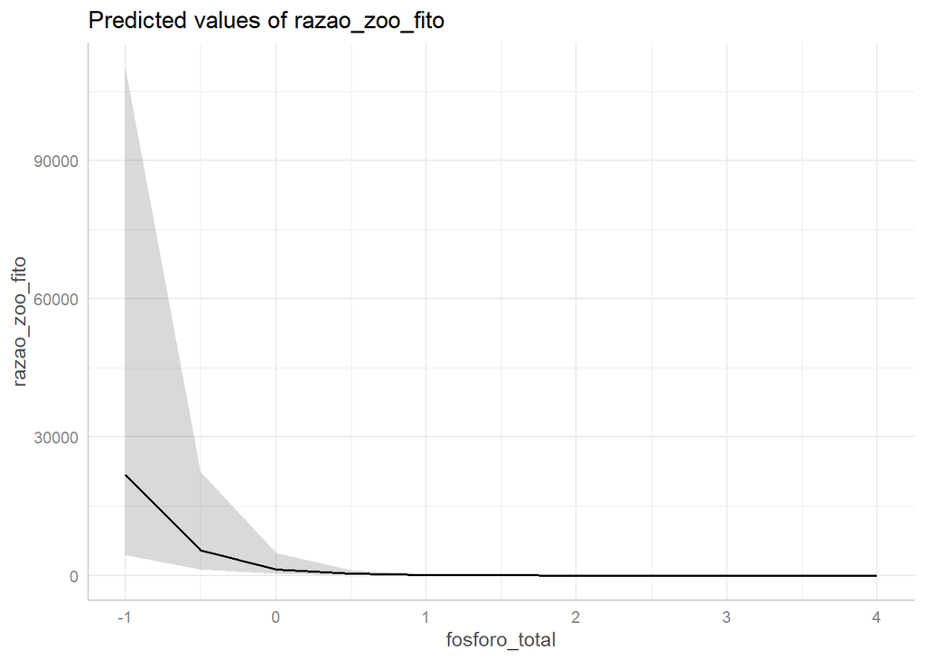

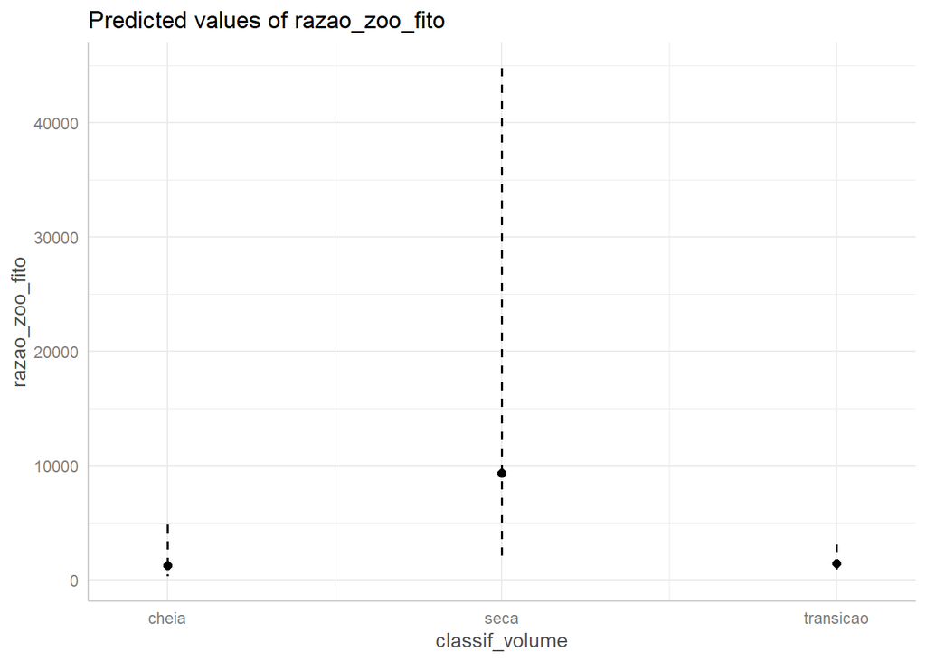

```r
### Plotando valores ajustados
library(ggeffects)
ggpredict(modelo_G3) %>% plot()
```

- É percepitível alguns problemas de previsão de valores. Valores muito altos não estão sendo muito bem preditos e alguns valores pequenos estão superestimados.

## 8 Conclusão

- De modo geral, o modelo se ajustou consideravelemente aos dados. Avaliando os coeficientes das variáveis do modelo, o aumento de fósforo e da profundidade máxima afetam negativamente a razão zoo/fito. O período hidrológico não foi significativo, mas o coeficiente positivo, é um indicativo de que no período de seca há mais chances da razão ser maior. Como as variáveis ambientais estão padronizadas, a interpretação em escala de medida é diferente, além disso, a função de ligação é log.